# MODELO DE PREDICCIÓN DEL NÚMERO DE HIJOS EN LOS HOGARES COLOMBIANOS

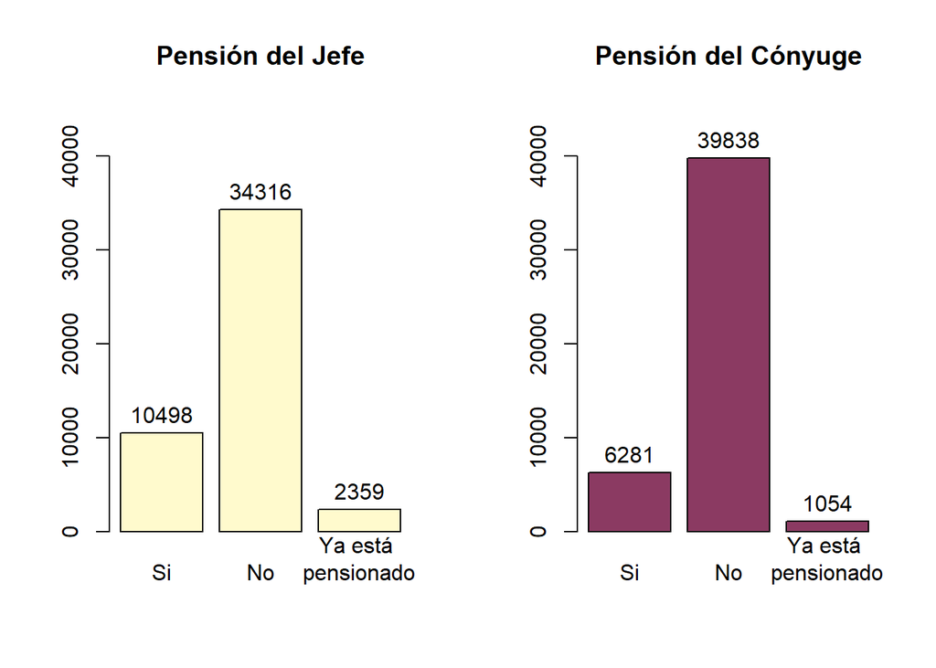

```r
par(mfrow=c(1,2))
#Jefe
Pension_jefe_table <- table(datos$Pension_Jefe)
Pension_jefe <- barplot(Pension_jefe_table, col = "lemonchiffon", main = "Pensión del Jefe",ylim = c(0,45000),names = c("Si","No","Ya está \npensionado"))
text(Pension_jefe,Pension_jefe_table+2000,labels = Pension_jefe_table)
#Conyuge
Pension_conyuge_table <- table(datos$Pension_Conyuge)
Pension_conyuge <- barplot(Pension_conyuge_table, col = "hotpink4", main = "Pensión del Cónyuge",ylim = c(0,45000),names = c("Si","No","Ya está \npensionado"))
text(Pension_conyuge,Pension_conyuge_table+2000,labels = Pension_conyuge_table)
```

**RECIBE_INGRESO_Jefe / RECIBE_INGRESO_Cónyuge**

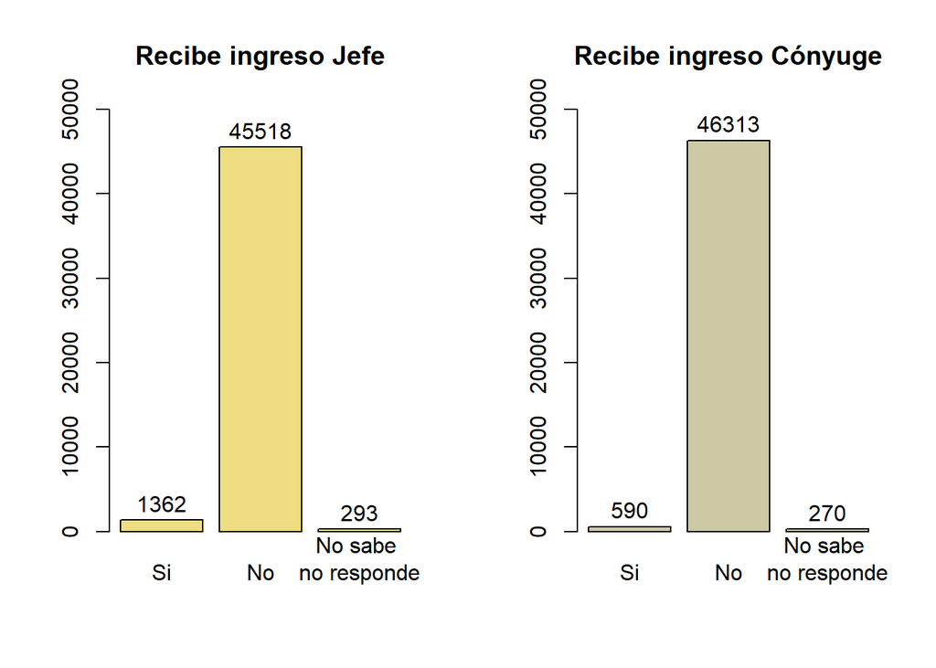

```r
par(mfrow=c(1,2))
#Jefe
Recibe_ingreso_jefe_table <- table(datos$Recibe_ingreso_Jefe)
Recibe_ingreso_jefe <- barplot(Recibe_ingreso_jefe_table, col = "lightgoldenrod", main = "Recibe ingreso Jefe",ylim = c(0,50000),names = c("Si","No","No sabe \nno responde"))
text(Recibe_ingreso_jefe,Recibe_ingreso_jefe_table+2000,labels = Recibe_ingreso_jefe_table)
#Conyuge
Recibe_ingreso_conyuge_table <- table(datos$Recibe_ingreso_Conyuge)
Recibe_ingreso_conyuge <- barplot(Recibe_ingreso_conyuge_table, col = "lemonchiffon3", main = "Recibe ingreso Cónyuge",ylim = c(0,50000),names = c("Si","No","No sabe \nno responde"))
text(Recibe_ingreso_conyuge,Recibe_ingreso_conyuge_table+2000,labels = Recibe_ingreso_conyuge_table)
```

**RECIBE_INGRESO_ALIMENTO_Jefe / RECIBE_INGRESO_ALIMENTO_Cónyuge**

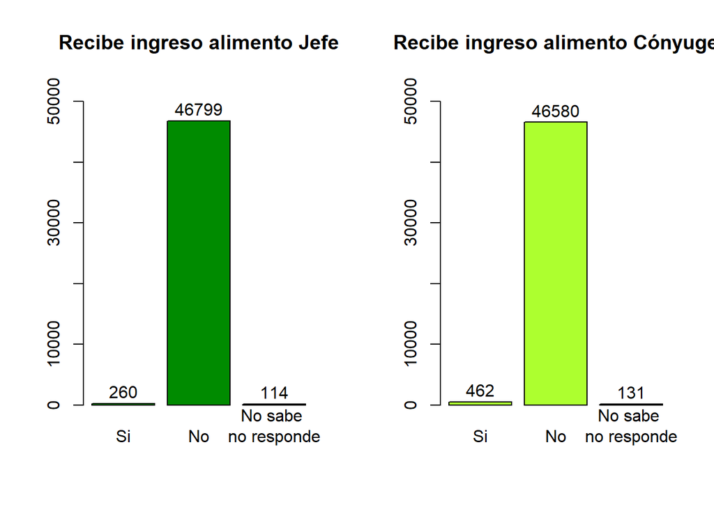

```r
par(mfrow=c(1,2))
#Jefe
Recibe_ingreso_alimento_jefe_table <- table(datos$Recibe_ingreso_alimento_Jefe)
Recibe_ingreso_alimento_jefe <- barplot(Recibe_ingreso_alimento_jefe_table, col = "green4", main = "Recibe ingreso alimento Jefe",ylim = c(0,53000),names = c("Si","No","No sabe \nno responde"))
text(Recibe_ingreso_alimento_jefe,Recibe_ingreso_alimento_jefe_table+2000,labels = Recibe_ingreso_alimento_jefe_table)
#Conyuge
Recibe_ingreso_alimento_conyuge_table <- table(datos$Recibe_ingreso_alimento_Conyuge)
Recibe_ingreso_alimento_conyuge <- barplot(Recibe_ingreso_alimento_conyuge_table, col = "greenyellow", main = "Recibe ingreso alimento Cónyuge",ylim = c(0,53000),names = c("Si","No","No sabe \nno responde"))
text(Recibe_ingreso_alimento_conyuge,Recibe_ingreso_alimento_conyuge_table+2000,labels = Recibe_ingreso_alimento_conyuge_table)
```

**RECIBE_INGRESO_BIENES_Jefe / RECIBE_INGRESO_BIENES_Cónyuge**

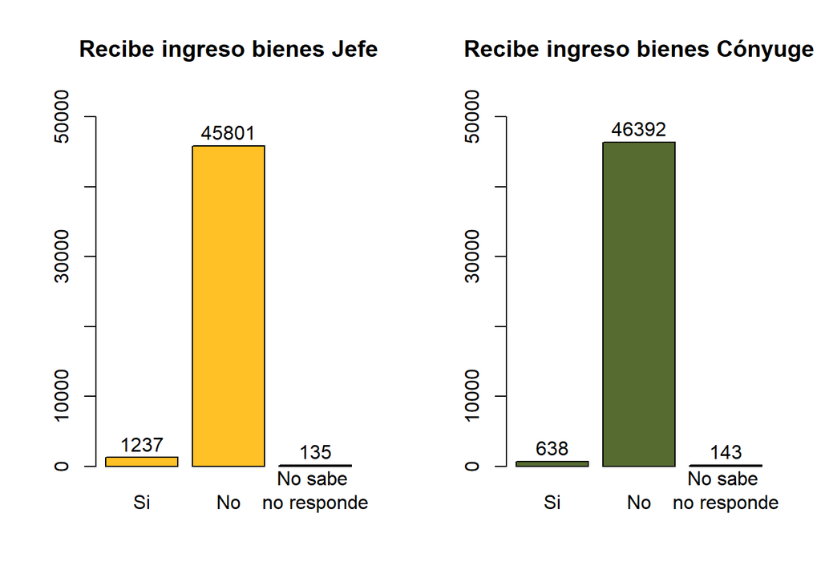

```r
par(mfrow=c(1,2))
#Jefe
Recibe_ingreso_bienes_jefe_table <- table(datos$Recibe_ingreso_bienes_Jefe)
Recibe_ingreso_bienes_jefe <- barplot(Recibe_ingreso_bienes_jefe_table, col = "goldenrod1", main = "Recibe ingreso bienes Jefe",ylim = c(0,53000),names = c("Si","No","No sabe \nno responde"))
text(Recibe_ingreso_bienes_jefe,Recibe_ingreso_bienes_jefe_table+2000,labels = Recibe_ingreso_bienes_jefe_table)
#Conyuge
Recibe_ingreso_bienes_conyuge_table <- table(datos$Recibe_ingreso_bienes_Conyuge)
Recibe_ingreso_bienes_conyuge <- barplot(Recibe_ingreso_bienes_conyuge_table, col = "darkolivegreen", main = "Recibe ingreso bienes Cónyuge",ylim = c(0,53000),names = c("Si","No","No sabe \nno responde"))
text(Recibe_ingreso_bienes_conyuge,Recibe_ingreso_bienes_conyuge_table+2000,labels = Recibe_ingreso_bienes_conyuge_table)
```

### Descripción de variables cuantitativas

**EDAD_Jefe / EDAD_Cónyuge**

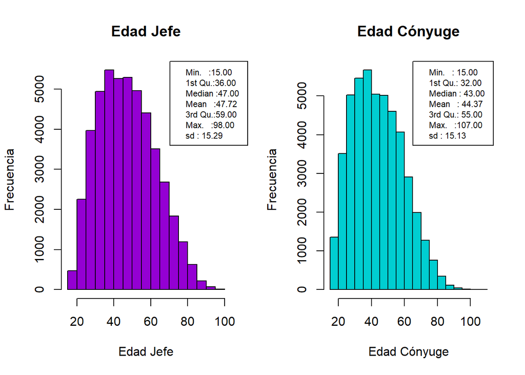

```r
par(mfrow=c(1,2))
estadisticas <- summary(datos[,c(3, 46)])
desviacion_estandar <- apply(datos[,c(3, 46)],2,sd)
Edad_jefe <- hist(datos$Edad_Jefe,xlab="Edad Jefe",ylab="Frecuencia",main="Edad Jefe",col="darkviolet")
legend("topright",legend= c(estadisticas[,1],paste("sd :",round(desviacion_estandar[1],2))),xpd = TRUE,cex = 0.7,inset = c(-0.1,0) )
Edad_conyuge <- hist(datos$Edad_Conyuge, xlab="Edad Cónyuge", ylab="Frecuencia", main="Edad Cónyuge", col= "darkturquoise")
legend("topright",legend= c(estadisticas[,2],paste("sd :",round(desviacion_estandar[2],2))),xpd = TRUE,cex = 0.7,inset = c(0,0) )
```

```r
#kable(summary(datos[,c(3, 46)]),caption="Edades")
#kable(t(apply(datos[,c(3, 46)],2,sd)), caption="Desviación estandar")
#hist(datos$Edad_Jefe, xlab="Edad Jede", ylab="Frecuencia", main="Edad Jefe", col = "darkviolet")
#hist(datos$Edad_Conyuge, xlab="Edad Cónyuge", ylab="Frecuencia", main="Edad Cónyuge", col= "darkturquoise")
```

**NÚMERO_DE_CUARTOS**

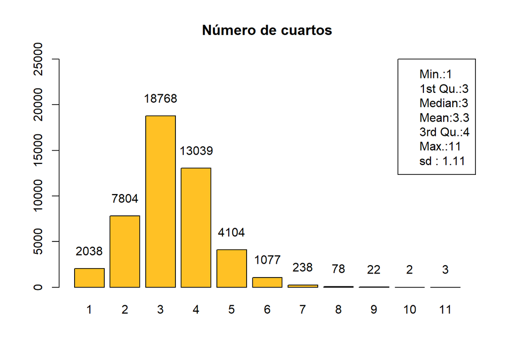

```r
estadisticas <- summary(datos$Num_Cuartos)
desviacion_estandar <- sd(datos$Num_Cuartos)
Num_cuartos_table <- table(datos$Num_Cuartos)
Num_cuartos <- barplot(Num_cuartos_table, col = "goldenrod1", main = "Número de cuartos",ylim = c(0,25000))
text(Num_cuartos,Num_cuartos_table+2000,labels = Num_cuartos_table)
legend("topright",legend= c(paste(names(estadisticas),round(estadisticas,2),sep = ":"),paste("sd :",round(desviacion_estandar,2))),xpd = TRUE,cex = 1,inset = c(0,0) )
```

**NÚMERO_DE_CUARTOS_PARA_DORMIR**

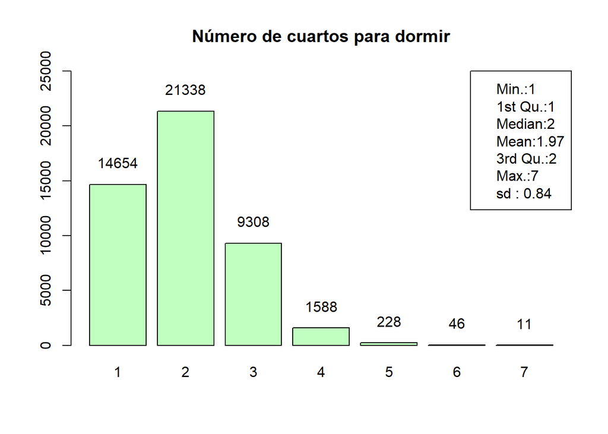

```r
estadisticas <- summary(datos$Num_cuartos_para_dormir)
desviacion_estandar <- sd(datos$Num_cuartos_para_dormir)
Num_cuartos_dormir_table <- table(datos$Num_cuartos_para_dormir)
Num_cuartos_dormir <- barplot(Num_cuartos_dormir_table, col = "darkseagreen1", main = "Número de cuartos para dormir",ylim = c(0,25000))
text(Num_cuartos_dormir,Num_cuartos_dormir_table+2000,labels = Num_cuartos_dormir_table)
legend("topright",legend= c(paste(names(estadisticas),round(estadisticas,2),sep = ":"),paste("sd :",round(desviacion_estandar,2))),xpd = TRUE,cex = 1,inset = c(0,0) )
```

**INGRESO_HOGAR**

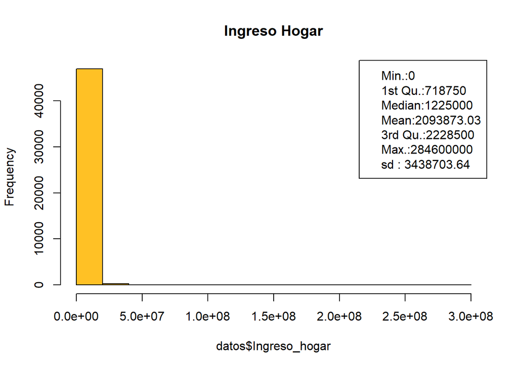

```r
estadisticas <- summary(datos$Ingreso_hogar)
desviacion_estandar <- sd(datos$Ingreso_hogar)
#Ingreso_hogar_table <- table(datos$Ingreso_hogar)
Ingreso_hogar <- hist(datos$Ingreso_hogar, col = "goldenrod1", main = "Ingreso Hogar")
#text(Ingreso_hogar,Ingreso_hogar_table+2000,labels = Ingreso_hogar_table)
legend("topright",legend= c(paste(names(estadisticas),round(estadisticas,2),sep = ":"),paste("sd :",round(desviacion_estandar,2))),xpd = TRUE,cex = 1,inset = c(0,0) )
```

**INGRESO_PÉRCAPITA_HOGAR**

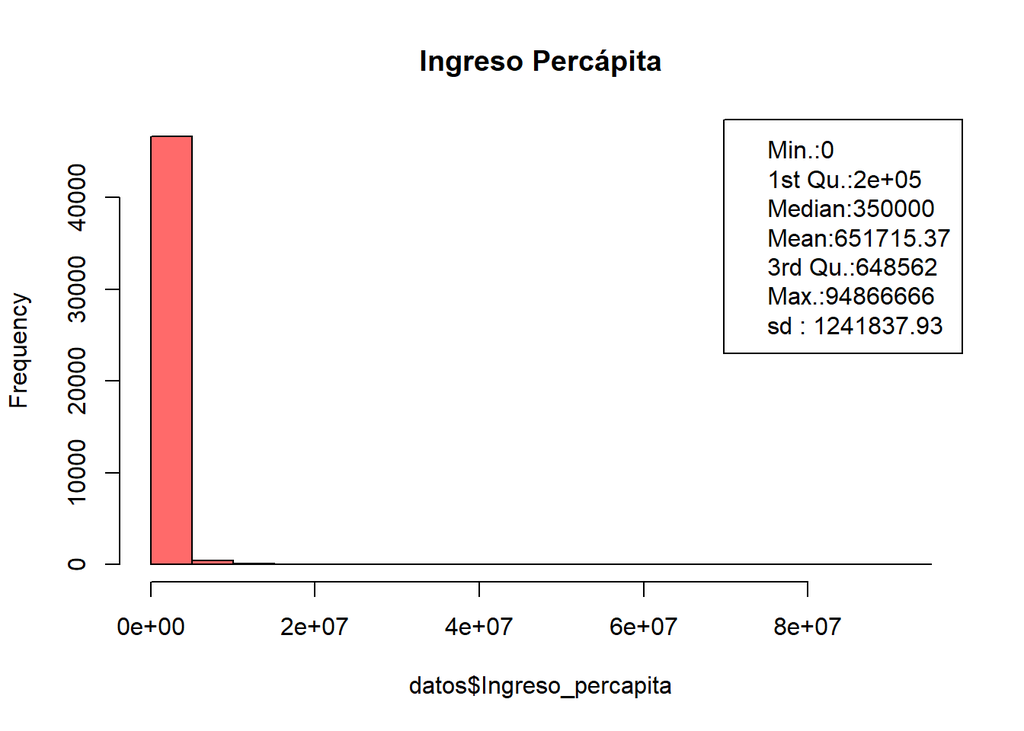

```r
estadisticas <- summary(datos$Ingreso_percapita)
desviacion_estandar <- sd(datos$Ingreso_percapita)
#Ingreso_hogar_table <- table(datos$Ingreso_percapita)
Ingreso_hogar <- hist(datos$Ingreso_percapita, col = "indianred1", main = "Ingreso Percápita")
#text(Ingreso_hogar,Ingreso_hogar_table+2000,labels = Ingreso_hogar_table)
legend("topright",legend= c(paste(names(estadisticas),round(estadisticas,2),sep = ":"),paste("sd :",round(desviacion_estandar,2))),xpd = TRUE,cex = 1,inset = c(0,0) )
```

**CANTIDAD_PERSONAS**

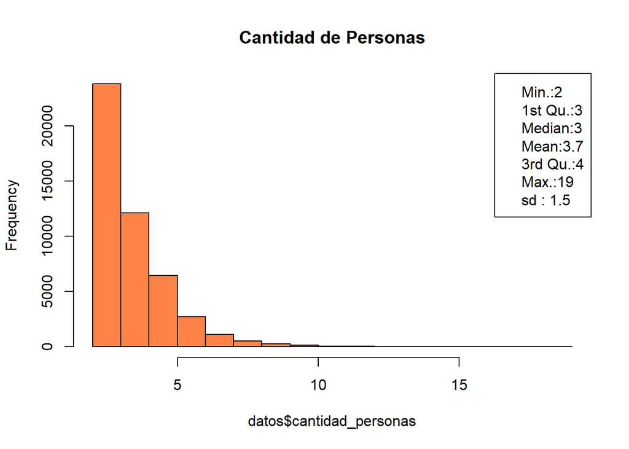

```r
estadisticas <- summary(datos$cantidad_personas)
desviacion_estandar <- sd(datos$cantidad_personas)
#Ingreso_hogar_table <- table(datos$Ingreso_percapita)
Ingreso_hogar <- hist(datos$cantidad_personas, col = "sienna1", main = "Cantidad de Personas")
#text(Ingreso_hogar,Ingreso_hogar_table+2000,labels = Ingreso_hogar_table)
legend("topright",legend= c(paste(names(estadisticas),round(estadisticas,2),sep = ":"),paste("sd :",round(desviacion_estandar,2))),xpd = TRUE,cex = 1,inset = c(0,0) )
```

**HIJOS**

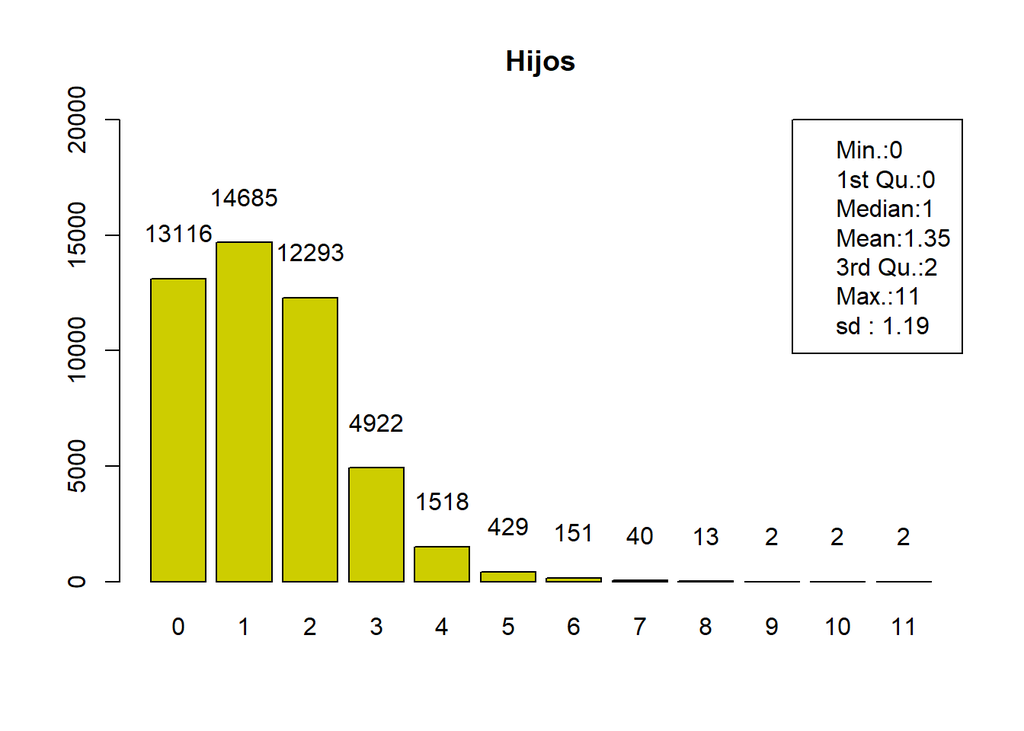

```r
estadisticas <- summary(datos$Hijos_x)
desviacion_estandar <- sd(datos$Hijos_x)
Hijos_table <- table(datos$Hijos_x)
Hijos <- barplot(Hijos_table, col = "yellow3", main = "Hijos",ylim = c(0,20000))
text(Hijos,Hijos_table+2000,labels = Hijos_table)
legend("topright",legend= c(paste(names(estadisticas),round(estadisticas,2),sep = ":"),paste("sd :",round(desviacion_estandar,2))),xpd = TRUE,cex = 1,inset = c(0,0) )
```

Finalmente, a modo de resumen, se obtienen los siguientes resultados:

```r
library(Hmisc)
library(knitr)
library(pastecs)
library(kableExtra)
#d <- t(stat.desc(datos))
d <- t(stat.desc(datos))
d <- d[,-c(1,3,6,7,10,11,14)]
colnames(d) <- c("Nulos","Mínimo","Máximo","Mediana","Media","varianza","Desviación estándar")

d %>%
  kbl(caption= "tabla") %>%
  kable_styling()
```

tabla

|  | Nulos | Mínimo | Máximo | Mediana | Media | varianza | Desviación estándar |
| --- | --- | --- | --- | --- | --- | --- | --- |
| Hijos_x | 13116 | 0 | 11 | 1 | 1.348314e+00 | 1.404262e+00 | 1.185016e+00 |
| Sexo_Jefe | 0 | 1 | 2 | 1 | 1.162720e+00 | 1.362452e-01 | 3.691141e-01 |
| Edad_Jefe | 0 | 15 | 98 | 47 | 4.772272e+01 | 2.336960e+02 | 1.528712e+01 |
| Parentesco_Jefe | 0 | 1 | 1 | 1 | 1.000000e+00 | 0.000000e+00 | 0.000000e+00 |
| Estado_civil_Jefe | 0 | 1 | 6 | 2 | 3.564921e+00 | 4.003062e+00 | 2.000765e+00 |
| Conyuge_Jefe | 0 | 1 | 1 | 1 | 1.000000e+00 | 0.000000e+00 | 0.000000e+00 |
| Padre_vive_Jefe | 0 | 1 | 3 | 2 | 2.467471e+00 | 2.604370e-01 | 5.103303e-01 |
| Madre_vive_Jefe | 0 | 1 | 3 | 2 | 2.338817e+00 | 2.503539e-01 | 5.003537e-01 |
| Cultura_Jefe | 0 | 1 | 6 | 6 | 5.527781e+00 | 1.768058e+00 | 1.329684e+00 |
| Campesino_Jefe | 0 | 1 | 9 | 1 | 1.412567e+00 | 4.501109e-01 | 6.709030e-01 |
| Satisfaccion_vida_Jefe | 214 | 0 | 10 | 8 | 8.203209e+00 | 2.938693e+00 | 1.714262e+00 |
| Satisfaccion_economica_Jefe | 921 | 0 | 99 | 7 | 1.275861e+01 | 5.239676e+02 | 2.289034e+01 |
| Satisfaccion_salud_Jefe | 315 | 0 | 10 | 8 | 7.781634e+00 | 3.784058e+00 | 1.945266e+00 |
| Satisfaccion_trabajo_Jefe | 891 | 0 | 10 | 8 | 7.444640e+00 | 4.805874e+00 | 2.192230e+00 |
| Felicidad_Jefe | 594 | 0 | 10 | 8 | 7.907447e+00 | 4.177816e+00 | 2.043970e+00 |
| Tristeza_Jefe | 23635 | 0 | 10 | 0 | 1.829966e+00 | 6.100041e+00 | 2.469826e+00 |
| Escalon_vida_Jefe | 201 | 0 | 10 | 8 | 7.638374e+00 | 3.263716e+00 | 1.806576e+00 |
| REGION | 0 | 1 | 9 | 3 | 3.646705e+00 | 7.316925e+00 | 2.704982e+00 |
| Ubicacion | 0 | 1 | 2 | 1 | 1.464037e+00 | 2.487119e-01 | 4.987102e-01 |
| Tipo_vivienda | 0 | 1 | 5 | 1 | 1.235559e+00 | 2.460882e-01 | 4.960728e-01 |
| Material_exterior | 0 | 1 | 9 | 1 | 1.749348e+00 | 2.437554e+00 | 1.561267e+00 |
| Material_piso | 0 | 1 | 7 | 5 | 5.096432e+00 | 1.276909e+00 | 1.130004e+00 |
| Material_techo | 0 | 1 | 7 | 3 | 3.081933e+00 | 1.399396e+00 | 1.182961e+00 |
| Estrato | 2483 | 0 | 6 | 1 | 1.564454e+00 | 1.011051e+00 | 1.005510e+00 |
| ORDEN | 0 | 1 | 1 | 1 | 1.000000e+00 | 0.000000e+00 | 0.000000e+00 |
| Num_Cuartos | 0 | 1 | 11 | 3 | 3.299112e+00 | 1.223682e+00 | 1.106202e+00 |
| Num_cuartos_para_dormir | 0 | 1 | 7 | 2 | 1.973565e+00 | 7.068608e-01 | 8.407501e-01 |
| Ingreso_hogar | 435 | 0 | 284600000 | 1225000 | 2.093873e+06 | 1.182468e+13 | 3.438704e+06 |
| Ingreso_percapita | 441 | 0 | 94866666 | 350000 | 6.517154e+05 | 1.542161e+12 | 1.241838e+06 |
| cantidad_personas | 0 | 2 | 19 | 3 | 3.695716e+00 | 2.255285e+00 | 1.501761e+00 |
| Tiene_EPS_Jefe | 0 | 1 | 9 | 1 | 1.066288e+00 | 1.497439e-01 | 3.869675e-01 |
| Percepcion_Jefe | 0 | 1 | 9 | 2 | 2.520425e+00 | 1.739370e+00 | 1.318852e+00 |
| Prepagada_Jefe | 0 | 1 | 2 | 2 | 1.995591e+00 | 4.390000e-03 | 6.625670e-02 |
| Estado_salud_Jefe | 0 | 1 | 4 | 2 | 2.162042e+00 | 3.259847e-01 | 5.709507e-01 |
| Enfermedad_grave_Jefe | 0 | 1 | 2 | 2 | 1.805122e+00 | 1.569042e-01 | 3.961113e-01 |
| Sabe_escribir_leer_Jefe | 0 | 1 | 2 | 1 | 1.069998e+00 | 6.509940e-02 | 2.551458e-01 |
| Estudia._Jefe | 0 | 1 | 2 | 2 | 1.981833e+00 | 1.783750e-02 | 1.335571e-01 |
| Nivel_educativo_Jefe | 0 | 1 | 14 | 4 | 4.739067e+00 | 8.504519e+00 | 2.916251e+00 |
| Publico_privado_Jefe | 0 | 1 | 3 | 3 | 2.969559e+00 | 5.406360e-02 | 2.325157e-01 |
| Actividad_Jefe | 0 | 1 | 6 | 1 | 1.803320e+00 | 2.233469e+00 | 1.494479e+00 |
| Pension_Jefe | 0 | 1 | 3 | 2 | 1.827465e+00 | 2.427867e-01 | 4.927340e-01 |
| Recibe_ingreso_Jefe | 0 | 1 | 9 | 2 | 2.014606e+00 | 3.330140e-01 | 5.770737e-01 |
| Recibe_ingreso_alimento_Jefe | 0 | 1 | 9 | 2 | 2.011405e+00 | 1.237994e-01 | 3.518514e-01 |
| Recibe_ingreso_bienes_Jefe | 0 | 1 | 9 | 2 | 1.993810e+00 | 1.664164e-01 | 4.079416e-01 |
| Sexo_Conyuge | 0 | 1 | 2 | 2 | 1.837343e+00 | 1.362023e-01 | 3.690560e-01 |
| Edad_Conyuge | 0 | 15 | 107 | 43 | 4.437259e+01 | 2.289711e+02 | 1.513179e+01 |
| Parentesco_Conyuge | 0 | 2 | 2 | 2 | 2.000000e+00 | 0.000000e+00 | 0.000000e+00 |
| Estado_civil_Conyuge | 0 | 1 | 6 | 2 | 3.564921e+00 | 4.003062e+00 | 2.000765e+00 |
| Conyuge_Conyuge | 0 | 1 | 1 | 1 | 1.000000e+00 | 0.000000e+00 | 0.000000e+00 |
| Padre_vive_Conyuge | 0 | 1 | 3 | 2 | 2.409429e+00 | 2.530799e-01 | 5.030705e-01 |
| Madre_vive_Conyuge | 0 | 1 | 3 | 2 | 2.287474e+00 | 2.328620e-01 | 4.825578e-01 |
| Cultura_Conyuge | 0 | 1 | 6 | 6 | 5.521167e+00 | 1.819260e+00 | 1.348799e+00 |
| Campesino_Conyuge | 0 | 1 | 9 | 1 | 1.448668e+00 | 5.026064e-01 | 7.089474e-01 |
| Satisfaccion_vida_Conyuge | 224 | 0 | 10 | 8 | 8.210693e+00 | 2.907592e+00 | 1.705166e+00 |
| Satisfaccion_economica_Conyuge | 750 | 0 | 99 | 8 | 3.387325e+01 | 1.778043e+03 | 4.216684e+01 |
| Satisfaccion_salud_Conyuge | 360 | 0 | 10 | 8 | 7.707333e+00 | 3.839978e+00 | 1.959586e+00 |
| Satisfaccion_trabajo_Conyuge | 1432 | 0 | 10 | 8 | 7.208000e+00 | 5.772939e+00 | 2.402694e+00 |
| Felicidad_Conyuge | 809 | 0 | 10 | 8 | 7.848197e+00 | 4.613371e+00 | 2.147876e+00 |
| Tristeza_Conyuge | 23361 | 0 | 10 | 1 | 1.920081e+00 | 6.579935e+00 | 2.565139e+00 |
| Escalon_vida_Conyuge | 207 | 0 | 10 | 8 | 7.714371e+00 | 3.234873e+00 | 1.798575e+00 |
| Tiene_EPS_Conyuge | 0 | 1 | 9 | 1 | 1.060480e+00 | 1.292388e-01 | 3.594980e-01 |
| Percepcion_Conyuge | 0 | 1 | 9 | 2 | 2.405910e+00 | 1.238735e+00 | 1.112985e+00 |
| Prepagada_Conyuge | 0 | 1 | 2 | 2 | 1.996566e+00 | 3.422400e-03 | 5.850170e-02 |
| Estado_salud_Conyuge | 0 | 1 | 4 | 2 | 2.189324e+00 | 3.099751e-01 | 5.567540e-01 |
| Enfermedad_grave_Conyuge | 0 | 1 | 2 | 2 | 1.787951e+00 | 1.670879e-01 | 4.087639e-01 |
| Sabe_escribir_leer_Conyuge | 0 | 1 | 2 | 1 | 1.063935e+00 | 5.984850e-02 | 2.446395e-01 |
| Estudia._Conyuge | 0 | 1 | 2 | 2 | 1.971022e+00 | 2.813930e-02 | 1.677477e-01 |
| Nivel_educativo_Conyuge | 0 | 1 | 14 | 4 | 4.920993e+00 | 9.105074e+00 | 3.017462e+00 |
| Publico_privado_Conyuge | 0 | 1 | 3 | 3 | 2.952134e+00 | 8.335280e-02 | 2.887088e-01 |
| Actividad_Conyuge | 0 | 1 | 6 | 4 | 2.993768e+00 | 2.213774e+00 | 1.487876e+00 |
| Pension_Conyuge | 0 | 1 | 3 | 2 | 1.889195e+00 | 1.432168e-01 | 3.784400e-01 |
| Recibe_ingreso_Conyuge | 0 | 1 | 9 | 2 | 2.027558e+00 | 2.922109e-01 | 5.405654e-01 |
| Recibe_ingreso_alimento_Conyuge | 0 | 1 | 9 | 2 | 2.009645e+00 | 1.457774e-01 | 3.818081e-01 |
| Recibe_ingreso_bienes_Conyuge | 0 | 1 | 9 | 2 | 2.007695e+00 | 1.620073e-01 | 4.025013e-01 |

### Exploración de relaciones

```r
library(gmodels)
library(Hmisc)
library(corrplot)
library(knitr)

kable(round(cor(datos),2))
```

|  | Hijos_x | Sexo_Jefe | Edad_Jefe | Parentesco_Jefe | Estado_civil_Jefe | Conyuge_Jefe | Padre_vive_Jefe | Madre_vive_Jefe | Cultura_Jefe | Campesino_Jefe | Satisfaccion_vida_Jefe | Satisfaccion_economica_Jefe | Satisfaccion_salud_Jefe | Satisfaccion_trabajo_Jefe | Felicidad_Jefe | Tristeza_Jefe | Escalon_vida_Jefe | REGION | Ubicacion | Tipo_vivienda | Material_exterior | Material_piso | Material_techo | Estrato | ORDEN | Num_Cuartos | Num_cuartos_para_dormir | Ingreso_hogar | Ingreso_percapita | … |
| --- | --- | --- | --- | --- | --- | --- | --- | --- | --- | --- | --- | --- | --- | --- | --- | --- | --- | --- | --- | --- | --- | --- | --- | --- | --- | --- | --- | --- | --- | --- |
| Hijos_x | 1.00 | 0.01 | -0.27 | NA | -0.11 | NA | -0.16 | -0.19 | -0.10 | 0.00 | -0.03 | 0.01 | 0.06 | -0.02 | -0.02 | 0.01 | -0.04 | -0.03 | 0.01 | -0.02 | 0.07 | 0.11 | 0.08 | -0.13 | NA | 0.08 | 0.44 | -0.01 | -0.16 | … |
| Sexo_Jefe | 0.01 | 1.00 | -0.10 | NA | -0.09 | NA | -0.05 | -0.07 | 0.01 | 0.06 | -0.02 | 0.30 | -0.02 | -0.05 | -0.03 | 0.05 | -0.01 | -0.03 | -0.08 | 0.04 | -0.01 | 0.01 | 0.00 | -0.02 | NA | -0.02 | 0.01 | -0.01 | -0.01 | … |
| Edad_Jefe | -0.27 | -0.10 | 1.00 | NA | 0.38 | NA | 0.55 | 0.56 | 0.02 | -0.09 | -0.04 | 0.02 | -0.24 | -0.07 | -0.04 | 0.03 | -0.01 | -0.06 | 0.02 | -0.13 | -0.06 | -0.06 | -0.05 | 0.13 | NA | 0.23 | 0.08 | 0.07 | 0.09 | … |
| Parentesco_Jefe | NA | NA | NA | 1 | NA | NA | NA | NA | NA | NA | NA | NA | NA | NA | NA | NA | NA | NA | NA | NA | NA | NA | NA | NA | NA | NA | NA | NA | NA | … |
| Estado_civil_Jefe | -0.11 | -0.09 | 0.38 | NA | 1.00 | NA | 0.20 | 0.20 | 0.07 | 0.03 | 0.04 | -0.02 | -0.06 | 0.03 | 0.03 | -0.01 | 0.05 | -0.03 | -0.06 | -0.01 | -0.13 | -0.19 | -0.17 | 0.25 | NA | 0.23 | 0.11 | 0.17 | 0.16 | … |
| Conyuge_Jefe | NA | NA | NA | NA | NA | 1 | NA | NA | NA | NA | NA | NA | NA | NA | NA | NA | NA | NA | NA | NA | NA | NA | NA | NA | NA | NA | NA | NA | NA | … |
| Padre_vive_Jefe | -0.16 | -0.05 | 0.55 | NA | 0.20 | NA | 1.00 | 0.49 | 0.04 | -0.09 | -0.03 | 0.00 | -0.15 | -0.05 | -0.03 | 0.01 | -0.02 | -0.06 | 0.03 | -0.08 | -0.03 | -0.02 | -0.02 | 0.07 | NA | 0.12 | 0.04 | 0.01 | 0.03 | … |
| Madre_vive_Jefe | -0.19 | -0.07 | 0.56 | NA | 0.20 | NA | 0.49 | 1.00 | 0.03 | -0.10 | -0.04 | 0.01 | -0.16 | -0.05 | -0.03 | 0.02 | -0.03 | -0.06 | 0.06 | -0.08 | -0.01 | 0.00 | -0.01 | 0.05 | NA | 0.10 | -0.01 | 0.00 | 0.02 | … |
| Cultura_Jefe | -0.10 | 0.01 | 0.02 | NA | 0.07 | NA | 0.04 | 0.03 | 1.00 | 0.01 | 0.04 | -0.03 | 0.00 | 0.03 | 0.03 | -0.02 | 0.04 | -0.17 | -0.07 | -0.02 | -0.20 | -0.14 | -0.14 | 0.18 | NA | 0.06 | 0.00 | 0.06 | 0.07 | … |
| Campesino_Jefe | 0.00 | 0.06 | -0.09 | NA | 0.03 | NA | -0.09 | -0.10 | 0.01 | 1.00 | 0.03 | 0.02 | 0.07 | 0.05 | 0.02 | 0.00 | 0.06 | 0.05 | -0.37 | 0.18 | -0.13 | -0.24 | -0.23 | 0.24 | NA | 0.08 | 0.04 | 0.16 | 0.15 | … |
| Satisfaccion_vida_Jefe | -0.03 | -0.02 | -0.04 | NA | 0.04 | NA | -0.03 | -0.04 | 0.04 | 0.03 | 1.00 | -0.02 | 0.45 | 0.46 | 0.45 | -0.29 | 0.48 | 0.00 | -0.01 | 0.01 | -0.06 | -0.08 | -0.05 | 0.11 | NA | 0.08 | 0.02 | 0.10 | 0.10 | … |
| Satisfaccion_economica_Jefe | 0.01 | 0.30 | 0.02 | NA | -0.02 | NA | 0.00 | 0.01 | -0.03 | 0.02 | -0.02 | 1.00 | -0.03 | -0.11 | -0.01 | 0.00 | -0.02 | 0.01 | -0.02 | 0.01 | 0.02 | 0.03 | 0.03 | -0.04 | NA | -0.03 | -0.01 | -0.04 | -0.04 | … |
| Satisfaccion_salud_Jefe | 0.06 | -0.02 | -0.24 | NA | -0.06 | NA | -0.15 | -0.16 | 0.00 | 0.07 | 0.45 | -0.03 | 1.00 | 0.43 | 0.39 | -0.27 | 0.37 | 0.00 | -0.02 | 0.05 | -0.03 | -0.05 | -0.03 | 0.08 | NA | 0.01 | 0.00 | 0.09 | 0.08 | … |
| Satisfaccion_trabajo_Jefe | -0.02 | -0.05 | -0.07 | NA | 0.03 | NA | -0.05 | -0.05 | 0.03 | 0.05 | 0.46 | -0.11 | 0.43 | 1.00 | 0.39 | -0.26 | 0.43 | 0.00 | 0.02 | 0.02 | -0.07 | -0.10 | -0.07 | 0.14 | NA | 0.08 | 0.02 | 0.13 | 0.13 | … |
| Felicidad_Jefe | -0.02 | -0.03 | -0.04 | NA | 0.03 | NA | -0.03 | -0.03 | 0.03 | 0.02 | 0.45 | -0.01 | 0.39 | 0.39 | 1.00 | -0.46 | 0.41 | -0.02 | 0.01 | 0.01 | -0.05 | -0.06 | -0.04 | 0.09 | NA | 0.05 | 0.00 | 0.08 | 0.08 | … |
| Tristeza_Jefe | 0.01 | 0.05 | 0.03 | NA | -0.01 | NA | 0.01 | 0.02 | -0.02 | 0.00 | -0.29 | 0.00 | -0.27 | -0.26 | -0.46 | 1.00 | -0.27 | 0.02 | -0.04 | 0.00 | 0.00 | 0.01 | -0.01 | -0.04 | NA | -0.02 | 0.02 | -0.03 | -0.03 | … |
| Escalon_vida_Jefe | -0.04 | -0.01 | -0.01 | NA | 0.05 | NA | -0.02 | -0.03 | 0.04 | 0.06 | 0.48 | -0.02 | 0.37 | 0.43 | 0.41 | -0.27 | 1.00 | -0.02 | -0.03 | 0.01 | -0.09 | -0.11 | -0.07 | 0.13 | NA | 0.10 | 0.02 | 0.12 | 0.12 | … |
| REGION | -0.03 | -0.03 | -0.06 | NA | -0.03 | NA | -0.06 | -0.06 | -0.17 | 0.05 | 0.00 | 0.01 | 0.00 | 0.00 | -0.02 | 0.02 | -0.02 | 1.00 | -0.05 | 0.03 | 0.15 | -0.05 | 0.03 | -0.03 | NA | 0.00 | 0.02 | 0.03 | 0.04 | … |
| Ubicacion | 0.01 | -0.08 | 0.02 | NA | -0.06 | NA | 0.03 | 0.06 | -0.07 | -0.37 | -0.01 | -0.02 | -0.02 | 0.02 | 0.01 | -0.04 | -0.03 | -0.05 | 1.00 | -0.29 | 0.26 | 0.37 | 0.34 | -0.35 | NA | -0.15 | -0.11 | -0.21 | -0.19 | … |
| Tipo_vivienda | -0.02 | 0.04 | -0.13 | NA | -0.01 | NA | -0.08 | -0.08 | -0.02 | 0.18 | 0.01 | 0.01 | 0.05 | 0.02 | 0.01 | 0.00 | 0.01 | 0.03 | -0.29 | 1.00 | -0.07 | -0.20 | -0.28 | 0.22 | NA | -0.12 | -0.08 | 0.10 | 0.11 | … |
| Material_exterior | 0.07 | -0.01 | -0.06 | NA | -0.13 | NA | -0.03 | -0.01 | -0.20 | -0.13 | -0.06 | 0.02 | -0.03 | -0.07 | -0.05 | 0.00 | -0.09 | 0.15 | 0.26 | -0.07 | 1.00 | 0.36 | 0.37 | -0.29 | NA | -0.19 | -0.10 | -0.14 | -0.13 | … |
| Material_piso | 0.11 | 0.01 | -0.06 | NA | -0.19 | NA | -0.02 | 0.00 | -0.14 | -0.24 | -0.08 | 0.03 | -0.05 | -0.10 | -0.06 | 0.01 | -0.11 | -0.05 | 0.37 | -0.20 | 0.36 | 1.00 | 0.48 | -0.47 | NA | -0.29 | -0.14 | -0.27 | -0.26 | … |
| Material_techo | 0.08 | 0.00 | -0.05 | NA | -0.17 | NA | -0.02 | -0.01 | -0.14 | -0.23 | -0.05 | 0.03 | -0.03 | -0.07 | -0.04 | -0.01 | -0.07 | 0.03 | 0.34 | -0.28 | 0.37 | 0.48 | 1.00 | -0.48 | NA | -0.20 | -0.10 | -0.24 | -0.24 | … |
| Estrato | -0.13 | -0.02 | 0.13 | NA | 0.25 | NA | 0.07 | 0.05 | 0.18 | 0.24 | 0.11 | -0.04 | 0.08 | 0.14 | 0.09 | -0.04 | 0.13 | -0.03 | -0.35 | 0.22 | -0.29 | -0.47 | -0.48 | 1.00 | NA | 0.29 | 0.11 | 0.44 | 0.43 | … |
| ORDEN | NA | NA | NA | NA | NA | NA | NA | NA | NA | NA | NA | NA | NA | NA | NA | NA | NA | NA | NA | NA | NA | NA | NA | NA | 1 | NA | NA | NA | NA | … |
| Num_Cuartos | 0.08 | -0.02 | 0.23 | NA | 0.23 | NA | 0.12 | 0.10 | 0.06 | 0.08 | 0.08 | -0.03 | 0.01 | 0.08 | 0.05 | -0.02 | 0.10 | 0.00 | -0.15 | -0.12 | -0.19 | -0.29 | -0.20 | 0.29 | NA | 1.00 | 0.58 | 0.26 | 0.20 | … |
| Num_cuartos_para_dormir | 0.44 | 0.01 | 0.08 | NA | 0.11 | NA | 0.04 | -0.01 | 0.00 | 0.04 | 0.02 | -0.01 | 0.00 | 0.02 | 0.00 | 0.02 | 0.02 | 0.02 | -0.11 | -0.08 | -0.10 | -0.14 | -0.10 | 0.11 | NA | 0.58 | 1.00 | 0.15 | 0.00 | … |
| Ingreso_hogar | -0.01 | -0.01 | 0.07 | NA | 0.17 | NA | 0.01 | 0.00 | 0.06 | 0.16 | 0.10 | -0.04 | 0.09 | 0.13 | 0.08 | -0.03 | 0.12 | 0.03 | -0.21 | 0.10 | -0.14 | -0.27 | -0.24 | 0.44 | NA | 0.26 | 0.15 | 1.00 | 0.94 | … |
| Ingreso_percapita | -0.16 | -0.01 | 0.09 | NA | 0.16 | NA | 0.03 | 0.02 | 0.07 | 0.15 | 0.10 | -0.04 | 0.08 | 0.13 | 0.08 | -0.03 | 0.12 | 0.04 | -0.19 | 0.11 | -0.13 | -0.26 | -0.24 | 0.43 | NA | 0.20 | 0.00 | 0.94 | 1.00 | … |
| cantidad_personas | 0.83 | 0.04 | -0.12 | NA | -0.07 | NA | -0.08 | -0.11 | -0.10 | 0.00 | -0.04 | 0.03 | 0.01 | -0.04 | -0.03 | 0.02 | -0.05 | -0.06 | -0.02 | -0.04 | 0.05 | 0.11 | 0.08 | -0.12 | NA | 0.17 | 0.56 | 0.01 | -0.16 | … |
| Tiene_EPS_Jefe | 0.02 | 0.00 | -0.10 | NA | -0.07 | NA | -0.05 | -0.04 | 0.02 | 0.02 | -0.03 | 0.01 | 0.01 | -0.03 | -0.01 | 0.02 | -0.04 | 0.00 | 0.01 | 0.05 | 0.02 | 0.02 | 0.01 | -0.03 | NA | -0.07 | -0.04 | -0.04 | -0.04 | … |
| Percepcion_Jefe | 0.00 | -0.03 | -0.09 | NA | -0.05 | NA | -0.03 | -0.03 | 0.03 | -0.02 | -0.06 | -0.01 | -0.03 | -0.05 | -0.05 | 0.03 | -0.08 | 0.02 | 0.02 | 0.04 | 0.02 | 0.01 | 0.01 | -0.01 | NA | -0.06 | -0.04 | 0.00 | 0.00 | … |
| Prepagada_Jefe | 0.01 | 0.00 | -0.01 | NA | -0.04 | NA | 0.00 | 0.00 | -0.01 | -0.04 | -0.03 | 0.01 | -0.02 | -0.04 | -0.02 | 0.01 | -0.03 | -0.01 | 0.05 | -0.03 | 0.03 | 0.06 | 0.06 | -0.13 | NA | -0.05 | -0.02 | -0.15 | -0.16 | … |
| Estado_salud_Jefe | -0.07 | 0.04 | 0.29 | NA | 0.09 | NA | 0.20 | 0.20 | 0.00 | -0.12 | -0.20 | 0.05 | -0.48 | -0.22 | -0.20 | 0.15 | -0.21 | -0.02 | 0.06 | -0.08 | 0.03 | 0.06 | 0.05 | -0.09 | NA | -0.01 | 0.00 | -0.10 | -0.10 | … |
| Enfermedad_grave_Jefe | 0.15 | -0.04 | -0.37 | NA | -0.17 | NA | -0.24 | -0.24 | -0.05 | 0.03 | 0.06 | -0.05 | 0.28 | 0.09 | 0.08 | -0.06 | 0.06 | 0.06 | 0.04 | 0.01 | 0.06 | 0.08 | 0.09 | -0.10 | NA | -0.10 | -0.02 | -0.04 | -0.05 | … |
| Sabe_escribir_leer_Jefe | -0.04 | -0.01 | 0.22 | NA | -0.02 | NA | 0.13 | 0.15 | -0.04 | -0.12 | -0.05 | 0.03 | -0.09 | -0.06 | -0.05 | 0.01 | -0.06 | -0.08 | 0.13 | -0.06 | 0.10 | 0.16 | 0.14 | -0.13 | NA | -0.06 | -0.03 | -0.09 | -0.08 | … |
| Estudia._Jefe | 0.01 | -0.06 | 0.13 | NA | 0.03 | NA | 0.07 | 0.07 | 0.02 | -0.05 | -0.02 | -0.02 | -0.04 | -0.02 | -0.01 | 0.01 | -0.01 | -0.03 | 0.07 | -0.05 | 0.02 | 0.05 | 0.03 | -0.04 | NA | 0.00 | 0.01 | -0.03 | -0.03 | … |
| Nivel_educativo_Jefe | -0.03 | 0.06 | -0.21 | NA | 0.09 | NA | -0.15 | -0.18 | 0.03 | 0.30 | 0.10 | -0.03 | 0.15 | 0.13 | 0.08 | -0.03 | 0.12 | 0.05 | -0.34 | 0.20 | -0.18 | -0.34 | -0.29 | 0.41 | NA | 0.17 | 0.05 | 0.39 | 0.38 | … |
| Publico_privado_Jefe | 0.01 | -0.06 | 0.13 | NA | 0.03 | NA | 0.06 | 0.07 | 0.02 | -0.05 | -0.02 | -0.02 | -0.03 | -0.01 | -0.01 | 0.01 | -0.01 | -0.03 | 0.07 | -0.05 | 0.01 | 0.05 | 0.02 | -0.03 | NA | 0.01 | 0.01 | -0.03 | -0.03 | … |
| Actividad_Jefe | -0.11 | 0.31 | 0.33 | NA | 0.12 | NA | 0.17 | 0.21 | -0.04 | 0.01 | -0.04 | 0.35 | -0.16 | -0.16 | -0.06 | 0.06 | -0.03 | 0.01 | -0.05 | 0.00 | 0.00 | -0.02 | -0.02 | 0.06 | NA | 0.07 | 0.00 | -0.02 | 0.00 | … |
| Pension_Jefe | -0.07 | 0.04 | 0.27 | NA | 0.03 | NA | 0.18 | 0.20 | -0.02 | -0.12 | -0.07 | 0.07 | -0.11 | -0.13 | -0.06 | 0.03 | -0.06 | -0.05 | 0.13 | -0.10 | 0.09 | 0.15 | 0.13 | -0.12 | NA | -0.03 | -0.06 | -0.14 | -0.10 | … |
| Recibe_ingreso_Jefe | 0.01 | 0.00 | -0.04 | NA | -0.02 | NA | -0.04 | -0.03 | -0.01 | 0.01 | -0.01 | 0.00 | 0.00 | -0.01 | -0.02 | 0.02 | -0.02 | 0.00 | 0.00 | 0.00 | 0.01 | 0.01 | 0.01 | -0.02 | NA | -0.02 | 0.01 | -0.03 | -0.04 | … |
| Recibe_ingreso_alimento_Jefe | 0.00 | -0.03 | 0.00 | NA | 0.00 | NA | -0.01 | -0.01 | 0.00 | 0.03 | 0.00 | -0.01 | 0.00 | 0.01 | -0.01 | 0.01 | 0.00 | 0.01 | -0.01 | 0.00 | 0.00 | -0.01 | -0.01 | 0.01 | NA | 0.01 | 0.01 | 0.00 | 0.00 | … |
| Recibe_ingreso_bienes_Jefe | 0.03 | 0.00 | -0.05 | NA | -0.03 | NA | -0.03 | -0.03 | -0.01 | 0.01 | -0.02 | 0.00 | 0.00 | -0.01 | -0.01 | 0.01 | -0.01 | 0.00 | 0.01 | -0.01 | 0.02 | 0.03 | 0.02 | -0.03 | NA | -0.03 | 0.01 | -0.05 | -0.05 | … |
| Sexo_Conyuge | -0.01 | -1.00 | 0.10 | NA | 0.09 | NA | 0.05 | 0.07 | -0.01 | -0.06 | 0.02 | -0.30 | 0.02 | 0.05 | 0.03 | -0.05 | 0.01 | 0.03 | 0.08 | -0.04 | 0.01 | -0.01 | 0.00 | 0.02 | NA | 0.01 | -0.01 | 0.01 | 0.01 | … |
| Edad_Conyuge | -0.29 | 0.09 | 0.87 | NA | 0.39 | NA | 0.48 | 0.50 | 0.02 | -0.07 | -0.04 | 0.07 | -0.22 | -0.08 | -0.05 | 0.04 | -0.01 | -0.07 | -0.01 | -0.11 | -0.07 | -0.07 | -0.06 | 0.14 | NA | 0.23 | 0.08 | 0.07 | 0.09 | … |
| Parentesco_Conyuge | NA | NA | NA | NA | NA | NA | NA | NA | NA | NA | NA | NA | NA | NA | NA | NA | NA | NA | NA | NA | NA | NA | NA | NA | NA | NA | NA | NA | NA | … |
| Estado_civil_Conyuge | -0.11 | -0.09 | 0.38 | NA | 1.00 | NA | 0.20 | 0.20 | 0.07 | 0.03 | 0.04 | -0.02 | -0.06 | 0.03 | 0.03 | -0.01 | 0.05 | -0.03 | -0.06 | -0.01 | -0.13 | -0.19 | -0.17 | 0.25 | NA | 0.23 | 0.11 | 0.17 | 0.16 | … |
| Conyuge_Conyuge | NA | NA | NA | NA | NA | NA | NA | NA | NA | NA | NA | NA | NA | NA | NA | NA | NA | NA | NA | NA | NA | NA | NA | NA | NA | NA | NA | NA | NA | … |
| Padre_vive_Conyuge | -0.18 | 0.03 | 0.48 | NA | 0.20 | NA | 0.38 | 0.38 | 0.03 | -0.08 | -0.02 | 0.04 | -0.14 | -0.05 | -0.02 | 0.01 | -0.02 | -0.06 | 0.02 | -0.06 | -0.03 | -0.02 | -0.03 | 0.06 | NA | 0.12 | 0.02 | 0.02 | 0.03 | … |
| Madre_vive_Conyuge | -0.19 | 0.04 | 0.50 | NA | 0.18 | NA | 0.36 | 0.38 | 0.02 | -0.08 | -0.03 | 0.04 | -0.15 | -0.06 | -0.03 | 0.02 | -0.02 | -0.05 | 0.04 | -0.07 | -0.01 | 0.00 | 0.00 | 0.04 | NA | 0.09 | -0.02 | -0.01 | 0.02 | … |
| Cultura_Conyuge | -0.11 | 0.03 | 0.02 | NA | 0.08 | NA | 0.04 | 0.03 | 0.81 | 0.00 | 0.03 | -0.02 | 0.00 | 0.03 | 0.03 | -0.02 | 0.04 | -0.19 | -0.07 | -0.01 | -0.21 | -0.14 | -0.14 | 0.18 | NA | 0.05 | -0.01 | 0.06 | 0.07 | … |
| Campesino_Conyuge | 0.00 | 0.01 | -0.08 | NA | 0.02 | NA | -0.08 | -0.08 | 0.01 | 0.50 | 0.03 | 0.00 | 0.07 | 0.04 | 0.02 | 0.00 | 0.05 | 0.04 | -0.36 | 0.18 | -0.12 | -0.22 | -0.21 | 0.23 | NA | 0.07 | 0.04 | 0.16 | 0.15 | … |
| Satisfaccion_vida_Conyuge | -0.02 | -0.04 | -0.05 | NA | 0.03 | NA | -0.03 | -0.03 | 0.03 | 0.03 | 0.51 | 0.00 | 0.35 | 0.36 | 0.37 | -0.24 | 0.40 | -0.01 | -0.01 | 0.01 | -0.06 | -0.08 | -0.05 | 0.11 | NA | 0.07 | 0.01 | 0.10 | 0.10 | … |
| Satisfaccion_economica_Conyuge | 0.02 | -0.23 | 0.02 | NA | 0.00 | NA | 0.03 | 0.04 | -0.01 | -0.09 | 0.02 | -0.01 | 0.01 | 0.01 | 0.03 | -0.07 | -0.01 | 0.00 | 0.13 | -0.04 | 0.07 | 0.09 | 0.07 | -0.09 | NA | -0.06 | -0.04 | -0.11 | -0.10 | … |
| Satisfaccion_salud_Conyuge | 0.05 | -0.01 | -0.21 | NA | -0.07 | NA | -0.14 | -0.14 | 0.00 | 0.08 | 0.34 | 0.01 | 0.42 | 0.31 | 0.29 | -0.21 | 0.31 | -0.01 | -0.03 | 0.05 | -0.03 | -0.04 | -0.03 | 0.08 | NA | 0.01 | -0.01 | 0.08 | 0.07 | … |
| Satisfaccion_trabajo_Conyuge | -0.02 | 0.00 | -0.04 | NA | 0.03 | NA | -0.02 | -0.03 | 0.03 | 0.04 | 0.31 | 0.00 | 0.27 | 0.41 | 0.27 | -0.18 | 0.30 | -0.02 | 0.01 | 0.01 | -0.07 | -0.09 | -0.07 | 0.13 | NA | 0.08 | 0.02 | 0.12 | 0.11 | … |
| Felicidad_Conyuge | -0.01 | -0.04 | -0.05 | NA | 0.02 | NA | -0.04 | -0.03 | 0.03 | 0.02 | 0.33 | 0.00 | 0.27 | 0.28 | 0.43 | -0.28 | 0.32 | -0.01 | 0.01 | 0.01 | -0.05 | -0.05 | -0.04 | 0.09 | NA | 0.04 | -0.01 | 0.07 | 0.07 | … |
| Tristeza_Conyuge | 0.00 | 0.01 | 0.04 | NA | 0.00 | NA | 0.02 | 0.02 | -0.01 | 0.00 | -0.21 | -0.01 | -0.19 | -0.18 | -0.27 | 0.44 | -0.20 | 0.01 | -0.04 | 0.00 | 0.01 | 0.00 | -0.02 | -0.03 | NA | -0.02 | 0.01 | -0.02 | -0.02 | … |
| Escalon_vida_Conyuge | -0.03 | -0.04 | -0.02 | NA | 0.06 | NA | -0.02 | -0.03 | 0.05 | 0.04 | 0.38 | -0.01 | 0.31 | 0.34 | 0.34 | -0.22 | 0.58 | -0.03 | -0.03 | 0.01 | -0.09 | -0.11 | -0.07 | 0.13 | NA | 0.10 | 0.02 | 0.12 | 0.12 | … |
| Tiene_EPS_Conyuge | 0.02 | 0.04 | -0.10 | NA | -0.07 | NA | -0.05 | -0.05 | 0.02 | 0.04 | -0.03 | 0.02 | 0.01 | -0.03 | -0.02 | 0.02 | -0.03 | 0.01 | -0.01 | 0.06 | 0.01 | 0.03 | 0.02 | -0.03 | NA | -0.07 | -0.04 | -0.04 | -0.04 | … |
| Percepcion_Conyuge | 0.00 | 0.05 | -0.08 | NA | -0.05 | NA | -0.03 | -0.03 | 0.03 | 0.00 | -0.06 | 0.02 | -0.04 | -0.05 | -0.05 | 0.03 | -0.08 | 0.03 | -0.01 | 0.05 | 0.01 | 0.01 | 0.01 | 0.00 | NA | -0.06 | -0.04 | 0.00 | 0.00 | … |
| Prepagada_Conyuge | 0.02 | 0.00 | -0.01 | NA | -0.05 | NA | 0.00 | 0.01 | -0.01 | -0.05 | -0.03 | 0.01 | -0.03 | -0.03 | -0.02 | 0.02 | -0.03 | -0.01 | 0.04 | -0.03 | 0.03 | 0.06 | 0.06 | -0.13 | NA | -0.05 | -0.01 | -0.16 | -0.16 | … |
| Estado_salud_Conyuge | -0.08 | -0.03 | 0.25 | NA | 0.09 | NA | 0.19 | 0.19 | 0.01 | -0.12 | -0.13 | 0.00 | -0.24 | -0.14 | -0.11 | 0.08 | -0.15 | -0.03 | 0.07 | -0.07 | 0.02 | 0.05 | 0.04 | -0.08 | NA | -0.01 | -0.01 | -0.09 | -0.08 | … |
| Enfermedad_grave_Conyuge | 0.16 | 0.04 | -0.35 | NA | -0.18 | NA | -0.23 | -0.23 | -0.06 | 0.05 | 0.04 | 0.00 | 0.13 | 0.05 | 0.04 | -0.03 | 0.03 | 0.06 | 0.01 | 0.03 | 0.05 | 0.06 | 0.07 | -0.08 | NA | -0.09 | -0.01 | -0.02 | -0.04 | … |
| Sabe_escribir_leer_Conyuge | -0.04 | 0.05 | 0.22 | NA | -0.03 | NA | 0.13 | 0.15 | -0.08 | -0.10 | -0.05 | 0.05 | -0.09 | -0.07 | -0.06 | 0.02 | -0.06 | -0.05 | 0.11 | -0.04 | 0.10 | 0.17 | 0.13 | -0.13 | NA | -0.06 | -0.03 | -0.08 | -0.08 | … |
| Estudia._Conyuge | 0.01 | 0.03 | 0.14 | NA | 0.06 | NA | 0.07 | 0.08 | 0.01 | -0.04 | -0.03 | 0.02 | -0.04 | -0.03 | -0.03 | 0.02 | -0.02 | -0.03 | 0.06 | -0.05 | 0.01 | 0.04 | 0.03 | -0.02 | NA | 0.02 | 0.03 | -0.03 | -0.03 | … |
| Nivel_educativo_Conyuge | -0.03 | -0.06 | -0.25 | NA | 0.07 | NA | -0.17 | -0.19 | 0.07 | 0.26 | 0.10 | -0.06 | 0.15 | 0.12 | 0.09 | -0.04 | 0.11 | 0.04 | -0.32 | 0.19 | -0.17 | -0.32 | -0.27 | 0.38 | NA | 0.14 | 0.03 | 0.35 | 0.35 | … |
| Publico_privado_Conyuge | 0.01 | 0.03 | 0.14 | NA | 0.06 | NA | 0.07 | 0.08 | 0.01 | -0.03 | -0.02 | 0.01 | -0.04 | -0.02 | -0.03 | 0.02 | -0.01 | -0.03 | 0.06 | -0.05 | 0.00 | 0.03 | 0.02 | -0.01 | NA | 0.02 | 0.03 | -0.02 | -0.02 | … |
| Actividad_Conyuge | -0.03 | -0.39 | 0.22 | NA | 0.07 | NA | 0.13 | 0.16 | -0.04 | -0.14 | -0.01 | -0.13 | -0.06 | -0.01 | -0.01 | -0.01 | -0.03 | -0.02 | 0.20 | -0.12 | 0.09 | 0.14 | 0.13 | -0.11 | NA | -0.03 | -0.05 | -0.16 | -0.14 | … |
| Pension_Conyuge | -0.03 | -0.08 | 0.17 | NA | 0.00 | NA | 0.12 | 0.14 | -0.02 | -0.13 | -0.05 | -0.02 | -0.08 | -0.05 | -0.04 | 0.02 | -0.05 | -0.05 | 0.17 | -0.11 | 0.10 | 0.17 | 0.14 | -0.16 | NA | -0.06 | -0.06 | -0.19 | -0.16 | … |
| Recibe_ingreso_Conyuge | 0.01 | 0.00 | -0.01 | NA | -0.01 | NA | -0.01 | -0.02 | 0.00 | 0.01 | -0.01 | 0.01 | -0.01 | -0.01 | -0.01 | 0.01 | -0.01 | 0.01 | -0.01 | 0.01 | 0.00 | 0.01 | 0.00 | 0.00 | NA | -0.01 | 0.01 | -0.02 | -0.02 | … |
| Recibe_ingreso_alimento_Conyuge | -0.01 | 0.01 | 0.01 | NA | 0.03 | NA | 0.01 | 0.00 | 0.00 | 0.02 | 0.00 | 0.00 | 0.00 | 0.00 | 0.00 | 0.01 | 0.00 | 0.01 | -0.01 | 0.00 | 0.00 | -0.01 | -0.01 | 0.02 | NA | 0.02 | 0.01 | 0.00 | 0.01 | … |
| Recibe_ingreso_bienes_Conyuge | 0.00 | 0.00 | -0.01 | NA | -0.01 | NA | -0.01 | -0.01 | -0.01 | 0.01 | 0.00 | -0.01 | 0.00 | 0.00 | 0.00 | 0.00 | 0.00 | 0.00 | 0.00 | -0.01 | 0.01 | 0.02 | 0.01 | -0.01 | NA | -0.01 | 0.00 | -0.03 | -0.03 | … |

Teniendo en cuenta las relaciones más relevantes alrededor de la variable hijos, se emplea en la tabla anterior, se realiza una descripción más profunda de las mismas, como sigue a continuación:

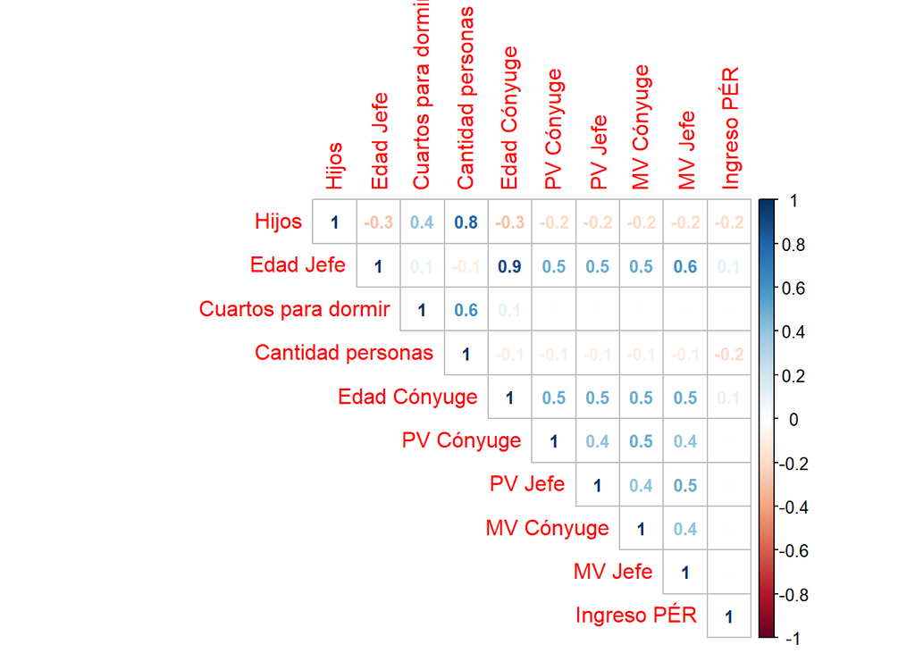

```r
d1 <- data.frame(datos$Hijos_x,datos$Edad_Jefe, datos$Num_cuartos_para_dormir, datos$cantidad_personas, datos$Edad_Conyuge, datos$Padre_vive_Conyuge, datos$Padre_vive_Jefe, datos$Madre_vive_Conyuge, datos$Madre_vive_Jefe, datos$Ingreso_percapita)
names(d1) = c("Hijos", "Edad Jefe", "Cuartos para dormir", "Cantidad personas", "Edad Cónyuge", "PV Cónyuge", "PV Jefe", "MV Cónyuge","MV Jefe", "Ingreso PÉR")
co <- round(cor(d1),1)
corrplot(co, method="number", type="upper",number.cex = 0.8)
```

Con lo anterior, se plantea de la misma manera realizar algunas gráficas que muestren el comportamiento de las variables que tienen relación con la variable hijos

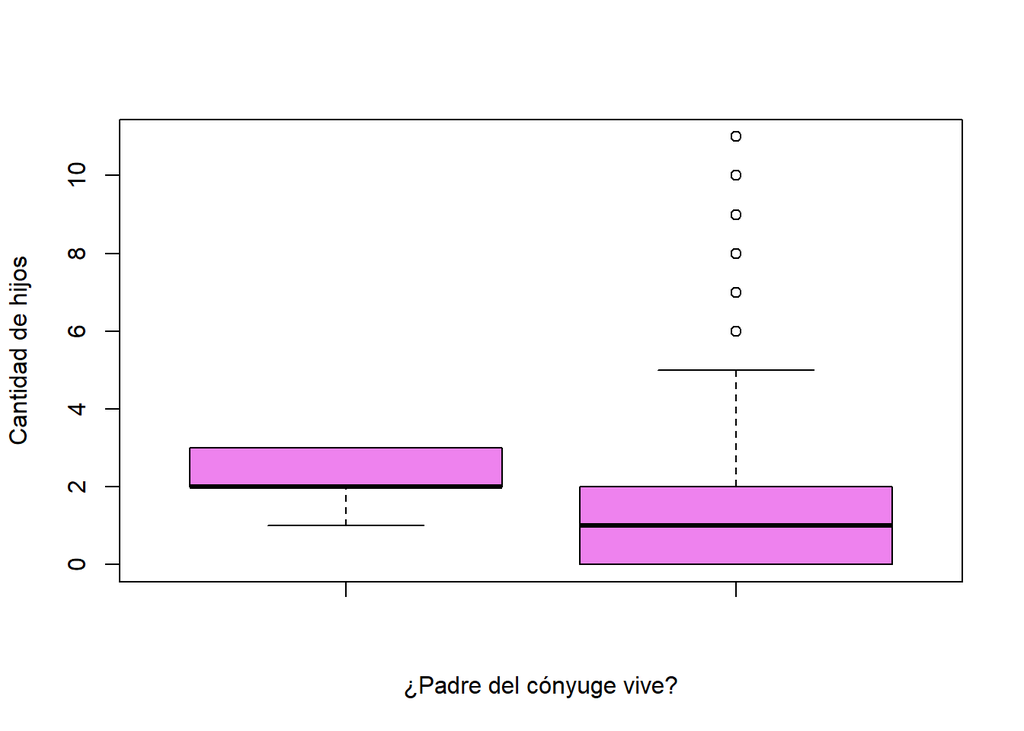

```r
boxplot(datos$Padre_vive_Conyuge, datos$Hijos_x, col ="violet", xlab="¿Padre del cónyuge vive?", ylab="Cantidad de hijos")
```

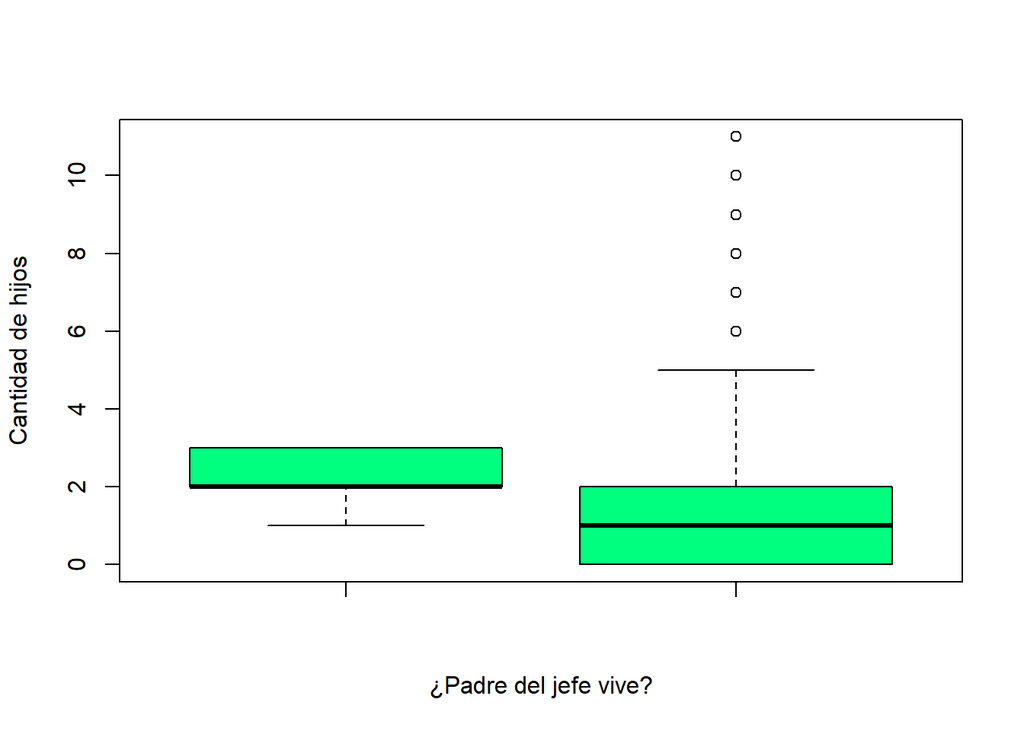

```r
boxplot(datos$Padre_vive_Jefe, datos$Hijos_x, col="springgreen", xlab="¿Padre del jefe vive?", ylab="Cantidad de hijos")
```

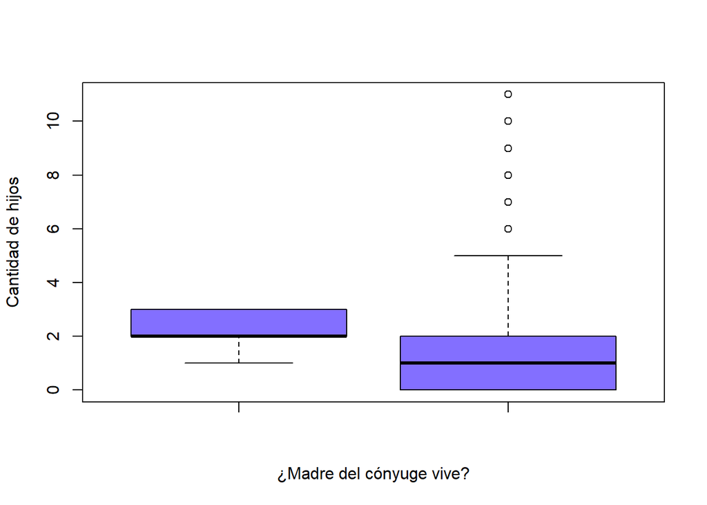

```r
boxplot(datos$Madre_vive_Conyuge, datos$Hijos_x, col="slateblue1",xlab="¿Madre del cónyuge vive?", ylab="Cantidad de hijos")
```

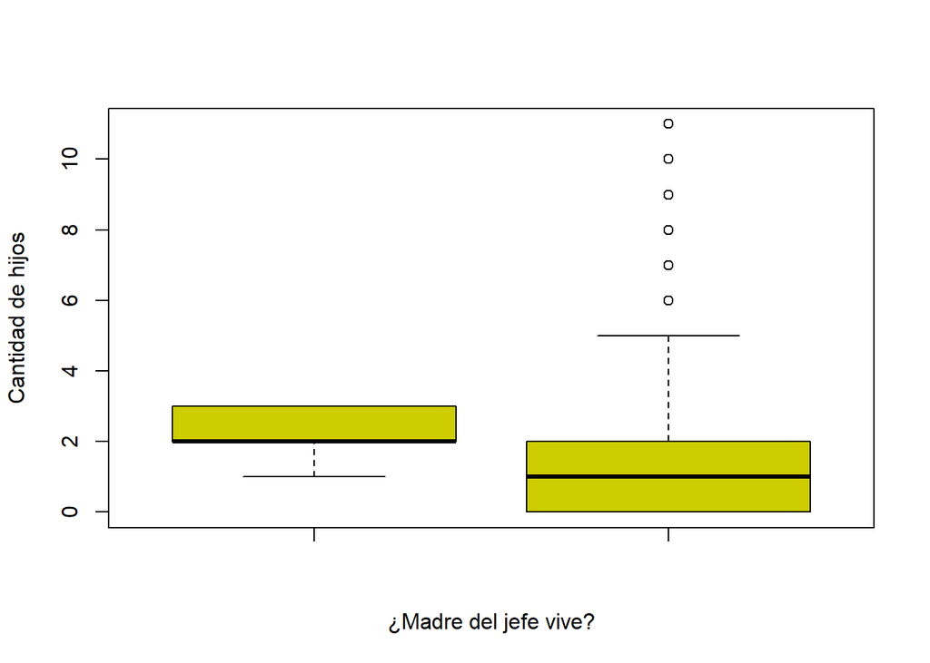

```r
boxplot(datos$Madre_vive_Jefe, datos$Hijos_x, col="yellow3", xlab="¿Madre del jefe vive?", ylab="Cantidad de hijos")
```

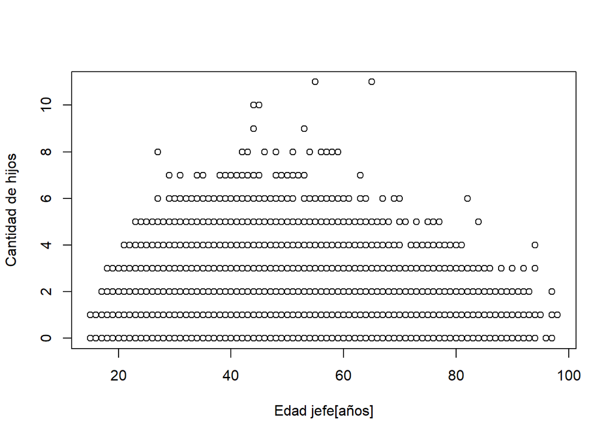

```r
plot(datos$Edad_Jefe, datos$Hijos_x, lty=2, xlab="Edad jefe[años]", ylab="Cantidad de hijos")
```

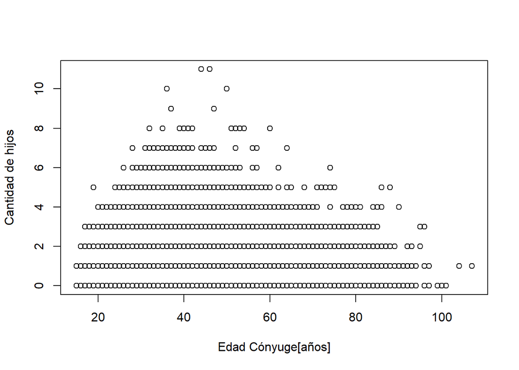

```r
plot(datos$Edad_Conyuge, datos$Hijos_x, lty=2, xlab="Edad Cónyuge[años]", ylab="Cantidad de hijos")
```

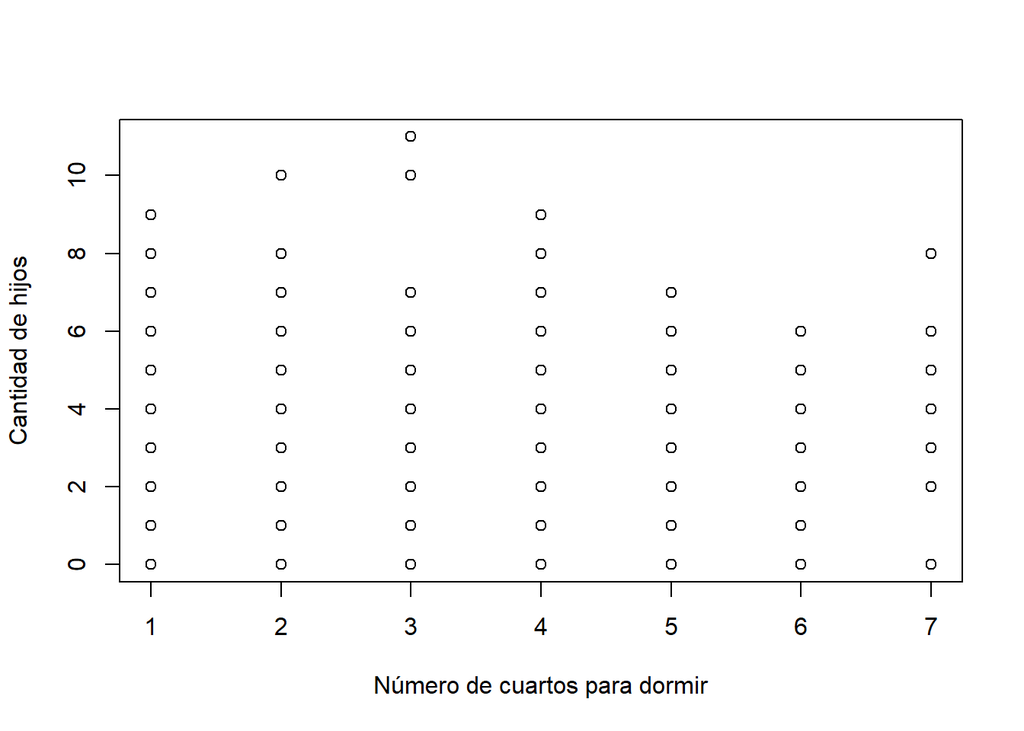

```r
plot(datos$Num_cuartos_para_dormir, datos$Hijos_x, lty=2, xlab="Número de cuartos para dormir", ylab="Cantidad de hijos")
```

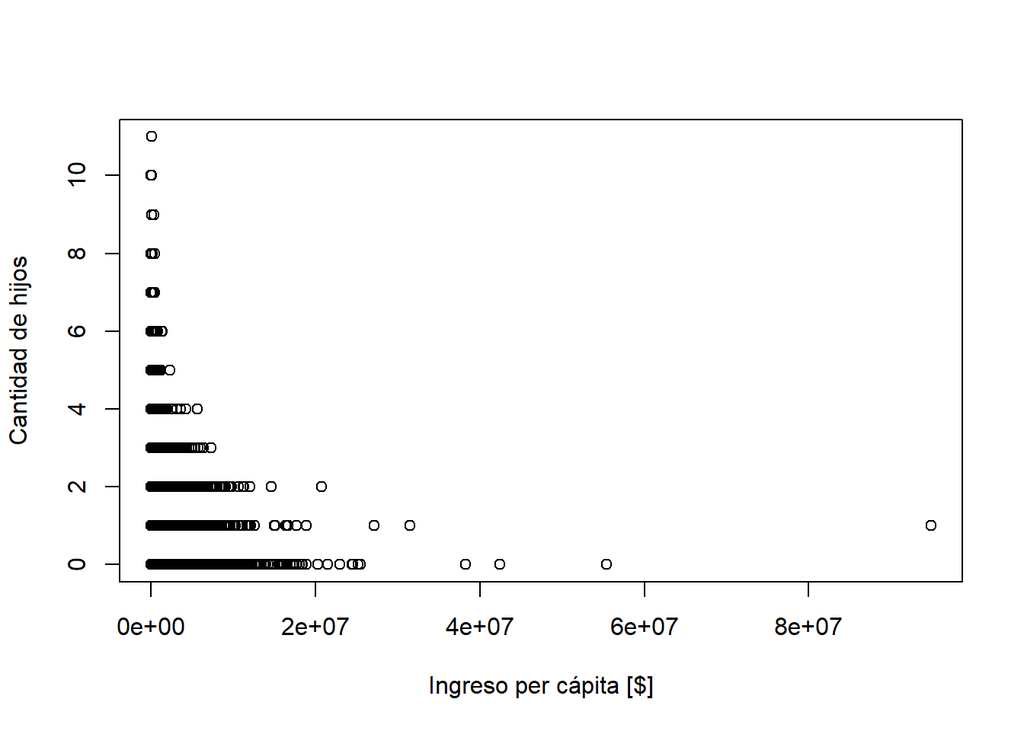

```r
plot(datos$Ingreso_percapita, datos$Hijos_x, lty=2, xlab="Ingreso per cápita [$]", ylab="Cantidad de hijos")
```

Con el análisis hecho, se procede desarrollar el modelo de predicción.

## Modelo propuesto

Debido a la conformación del equipo de trabajo, se selecciona el método de los **K-Nearest Neighbors (KNN)** con el fin de lograr un entendimiento total del modelo y de su estructura ya que, únicamente dos integrantes poseen el conocimiento suficiente para la realización de otros tipos de modelos que podrían ser o no más eficaces para el reto planteado, como el método de los bosques aleatorios o una regresión Poisson.

Aunque este método no es el más eficaz debido a las exigencias computacionales que demanda, se probaron 2 modelos diferentes obtenidos a partir de distintos enfoques, como se explica a continuación:

### Modelo 1:

Luego de hacer el tratamiento de los datos como se planteó anteriormente, se hace un pequeño filtrado con el fin de eliminar las variables poco relevantes o no aportantes en información, como el directorio del hogar, el ID del jefe y cónyuge del hogar, y la variable duplicada de hijos como se explicó anteriormente.

```r
datos <- read.csv("Datos/Datos_final.csv", header = TRUE, sep = ",") ## Cargando los datos
datos <- datos[, -c(1, 2, 47, 64)] ## Eliminando el directorio, el ID del jefe y conyugue e hijos_y, que es igual a la variable respuesta hijos
datos <- datos[, c(17, 1:16, 18:74)] ## Ordenando la base de datos para que hijos sea la primer columna
datos <- datos[, -c(4, 6, 25, 47, 49)]
```

Con lo anterior, se obtiene una tabla de datos con la variable respuesta como la primera columna, la cual corresponde al número de hijos por hogar.

Se procede entonces a realizar la estandarización de las variables para remover las unidades, debido a que el método de los **K-Nearest Neighbors (KNN)** es suceptible a ellas.

```r
estandar <- function(x){
  return((x - min(x)) / (max(x) - min(x)))
}
entradas <- as.data.frame(lapply(datos[,2:69], estandar)) ## estandarizar las variables de entrada
```

Luego, del total de datos, se selecciona un porcentaje para entrenamiento y un porcentaje para prueba. Con el fin de evitar overfitting o sobreentrenamiento en el modelo, se decide usar el 90% y el 10% de los datos para cada caso, respectivamente. Por último, se organiza cada una de las particiones con la variable respuesta, para proceder con el entrenamiento del modelo.

```r
set.seed(123) ## Se fija la semilla
aleatorio <- sample(1:nrow(datos), size=nrow(datos)*0.9) ## 10% para prueba con el fin de evitar overfitting
entradas_entre <- entradas[aleatorio, ] ## Se toman los datos de entrada para el entrenamiento
entradas_prueba <- entradas[-aleatorio, ] ## Se toman los datos de entrada para la prueba
Hijos <- datos[aleatorio, 1] ## Se coge la fila 1 que es la variable respuesta, para el entrenamiento.
Hijos_prueba <- datos[-aleatorio, 1] ## Se coge la fila 1 que es la variable respuesta, para la prueba
datos_entre <- cbind(Hijos, entradas_entre) ## Se concatenan la variable y los datos para obtener el conjunto completo de datos de entrenamiento
```

Por último, se hace la selección de las variables y el entrenamiento del modelo usando el método de validación cruzada con ayuda de las funciones **rfeControl***(Control de eliminación recursiva de variables)* y **rfe***(Eliminación recursiva de características)*.

```r
library(caret)
set.seed(123)
## Control de eliminación recursiva de variables
cer <- rfeControl(method = "cv",
                     number = 3,
                     returnResamp = "all",
                     functions = caretFuncs,
                     saveDetails = TRUE)

## Eliminación recursiva de características (Backward)
model <- rfe(Hijos ~ ., data = datos_entre, ## Modelo saturado
             sizes = 5:30,
             method = "knn",
             trControl = trainControl(method = "cv"),
             tuneLength = 20,
             rfeControl = cer)
```

### Modelo 2:

El modelo 2 toma el mismo procedimiento de desarrollo del modelo 1. Sin embargo, a diferencia del modelo 1, se contaba inicialmente con una base de datos con problemas estructurales debido a lo siguiente: - La base de datos contenía variables cualitativas dificilmente categorizables - Por hogar se contaba mínimamente con dos datos, uno referente al jefe del hogar y otro a su cónyuge, lo cual significaba que para dos unidades muestrales “diferentes” se obtenía el mismo resultado en la variable hijos. - Se seleccionaron las variables de manera arbitraria en la base de datos y posteriormente para el entrenamiento del modelo, se seleccionaron nuevamente otras variables sin argumentos estadísticos sólidos, tales como: edad, cultura, felicidad, ingreso del hogar, ingreso per cápita, nivel educativo y finalmente actividad.

A pesar de lo anterior, el entrenamiento y la validación del modelo se lleva a cabo por medio del lenguaje Python, como se muestra a continuación:

```
data.to_csv('Datos/data_modelo.csv', encoding = 'latin1', index = False)
Y = data['Hijos']
X = data.drop(['Hijos'], axis = 1)
# se dividen los datos entre entrenamiento 80# y validacion 20%
X_train, X_test, Y_train, Y_test = train_test_split(X, Y, test_size = 0.2)
# se genera el clasificador
clf = KNeighborsClassifier()
clf.fit(X_train, Y_train)
# se calcula la precision del modelo que es entre varia entre 76% a 78%
accuracy = clf.score(X_test, Y_test)
# EN ESTA FUNCION ENTRAN LAS "Y" ORIGINALES Y LAS PREDICCIONES PARA CREAR UNA MATRIZ DE CONFUSIÓN
def matconfision(y_test, y_pred):
    cm = confusion_matrix(y_test, y_pred)
    cmn = cm.astype('float') / cm.sum(axis=1)[:, np.newaxis]
    target_names = set(Y_test)

    fig, ax = plt.subplots(figsize = (10,10))
    sns.heatmap(cmn, annot=True, fmt='.2f', xticklabels=target_names, yticklabels=target_names)
    plt.xlabel('Predicted')

    return plt.show(block=False)
matconfision(Y_test, pred)
```

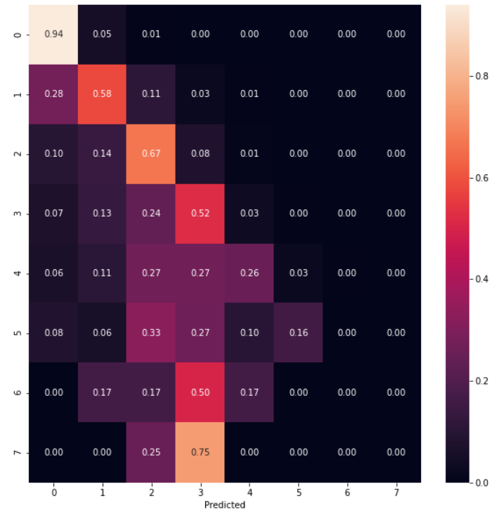

Matriz de confusión de Hijos

### Elección del modelo

Para la elección del modelo se tuvo en cuenta, más allá de los resultados obtenidos en la predicción y las métricas de evaluación, el proceso de selección, filtrado de datos y entrenamiento del modelo según las variables significativas. Se observaron entonces los siguientes comportamientos:

- Para el *modelo 2*, la base de datos usada en el entrenamiento presentaba inconsistencias, debido a que:
  - las variables finales que se usaron en el entrenamiento del modelo no estaban fundamentadas en criterios matemáticos, lo que daba paso a una selección final que podía no aportar información relevante, causando predicciones poco precisas según los datos suministrados.
  - Los datos por hogar se encontraban repetidos, en algunos casos más de una vez y por lo tanto, causaba errores en la predicción debido al mal entrenamiento del modelo.
  - Hubo una reducción drástica de datos de unidades muestrales debido a la eliminación inicial imprecisa de variables.
- Para el *modelo 1*, se contaba con una base de datos sólida, con buen filtrado y gran cantidad de observaciones. Además, se emplearon métodos estadísticos para seleccionar las variables importantes del modelo y los vecinos ideales para la predicción.

Teniendo en cuenta lo anterior, se selecciona el *modelo 1* debido a que cuenta con explicaciones estadísticas determinantes y explicativas. Además de que presenta una información menos empírica para las variables del modelo y los vecinos del mismo.

## Resultados del modelo seleccionado

Al realizar el entrenamiento del modelo con los comandos anteriormente mencionados, se obtiene la siguiente salida en el software R

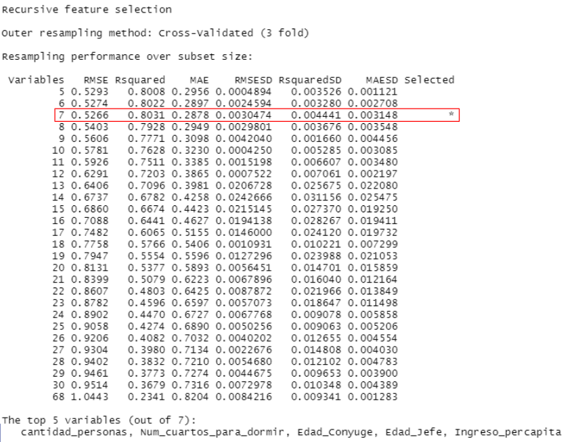

RESULTADOS DE LAS VARIABLES DEL MODELO

Según lo obtenido, poniendo como prioridad la métrica de evaluación **RMSE**, el software sugiere plantear el modelo por medio de $7$ variables, las cuales son:

```
Cantidad_personas

Número_cuartos_para_dormir

Edad_Cónyuge

Edad_Jefe

Ingreso_percapita

Madre_vive_cónyuge

Madre_vive_jefe
```

Posteriormente, se verifica el número de vecinos que sugiere el modelo para obtener los mínimos valores de *RMSE* según las variables seleccionadas, obteniendo la siguiente salida en el software:

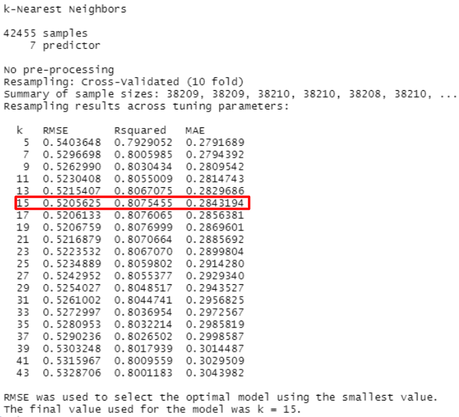

RESULTADOS DEL ENTRENAMIENTO DEL MODELO

Así, el modelo determina que es necesario hacer uso de 15 vecinos más cercanos para predecir y teniendo en cuenta estos resultados, se procede a diseñar la aplicación para el modelo seleccionado.

El modelo final, presenta los siguientes resultados respecto a las métricas de desempeño

```r
metrica <- c(0.5266,0.8031,0.2878,0.0030474,0.004441,0.003148, 0.2588047)
names(metrica) <- c("RMSE","Rsquared","MAE","RMSESD","RsquaredSD","MAESD Selected", "Error rate")
kable(t(metrica), caption = "MÉTRICAS DE DESEMPEÑO")
```

MÉTRICAS DE DESEMPEÑO

| RMSE | Rsquared | MAE | RMSESD | RsquaredSD | MAESD Selected | Error rate |
| --- | --- | --- | --- | --- | --- | --- |
| 0.5266 | 0.8031 | 0.2878 | 0.0030474 | 0.004441 | 0.003148 | 0.2588047 |

## Análisis de resultados

- El modelo presenta una tasa de error baja teniendo en cuenta que la mayoría de las variables explicativas de la base de datos tienen bajas correlaciones con la variable respuesta. Solo hay una variable que presenta alta correlación y es “Cantidad de personas”, explicando a dicha variable en un porcentaje cercano al 83%. Sin embargo, las demás variables no superan la correlación de 0.5, haciendo que el modelo sea entrenado con variables que explican poco a la variable requerida. No obstante, al implementar el método **KNN** se logra explicar la variable respuesta hasta en un 80%.
- Dentro de las variables explicativas importantes se evidencia la relevancia del área socioeconómica por medio del “ingreso per cápita” y de algunas otras variables características del hogar como la edad, la distribución de la casa y la cantidad de personas.
- La presencia de la madre de la pareja del hogar puede ser importante debido a que en la cultura de los hogares colombianos se acostumbra a que los abuelos cuiden de sus nietos, entonces su presencia podría explicar la presencia de hijos en el hogar.
- Al realizar la validación del modelo con los datos destinados para ello, respecto a las predicciones, se obtiene la siguiente matriz de confusión:

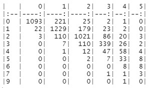

  MATRIZ DE CONFUSIÓN DEL MODELO FINAL

  En dicha matriz, se evidencia que el modelo predice en buena medida los resultados esperados de la variable respuesta hijos.

## Conclusiones

- Antes de apresurarse en la selección de un modelo para la solución de algún problema específico donde se necesite predecir, es de vital importancia tener una base de datos muy bien estructurada, con variables debidamente categorizadas, con respuestas acordes a cada una de las etiquetas y que aporten de manera significativa al modelo. Para ello, es necesario tener conocimientos sobre el uso de herramientas/comandos que ayuden con esta tarea, pues es el paso preliminar más importante cuando se trata de aprendizaje estadístico.
- Se observó en varias ocasiones que la correlación entre cada una de las variables y la variable respuesta podría arrojar resultados totalmente inesperados. Esto debido a que, según la literatura y siguiendo con un razonamiento personal frente a las variables consideradas relevantes, preguntas como el estrato socioeconómico o el estado de salud del jefe del hogar podían influir en gran medida con la cantidad de hijos, pero al hacer los respectivos análisis, tanto con la validación cruzada del modelo como en el análisis de correlación, no se obtenían tan buenos resultados con esas variables; he allí la importancia de este tipo de análisis para un buen entrenamiento.
- Como en cualquier búsqueda de soluciones a un problema, es de vital importancia conocer las características más importantes de este para poder plantear soluciones que sean óptimas. Por esta razón, aunque se mencionaron modelos más apropiados para el reto planteado, como por ejemplo el de bosques aleatorios, se hacía necesario también tener conocimientos técnicos básicos para el planteamiento del mismo, razón por la cual se descartó, para evitar confusiones y sobrecargas de trabajo a algunos miembros del equipo. Sin embargo, esta apreciación sirvió como sensibilización para tener presente que aunque el abanico de opciones es muy amplio, primero hay que conocerlo para poder tenerlo en cuenta como una alternativa.

## Aplicación

La aplicación web desarrollada para el modelo interactivo se puede encontrar aquí: https://trabajo1.shinyapps.io/pgina_web/

## Referencias

**[1].** OBSERVATORIO NACIONAL DE FAMILIAS, BOLETÍN # 2, departamento nacional de planeación, Bogotá d.c, julio 2014. [Online]. Available: https://observatoriodefamilia.dnp.gov.co/Documents/Boletines/bolet%C3%ADn-3---observatorio-de-familias.pdf.

**[2].** E.P. ROBAYO ESCOBAR, “TIPOLOGÍAS DEL HOGAR EN COLOMBIA (2000-2015): CARACTERÍSTICAS SOCIODEMOGRÁFICAS DE LAS MUJERES”, tesis, facultad de ciencias sociales y humanas, maestría en estudios de población, universidad externado de colombia, agosto 2019.

**[3].** J.S. ROMERO MORENO, “UN ACERCAMIENTO A LOS MODELOS ARIMAX Y LINEAL DINÁMICO PARA ESTIMAR NATALIDAD EN COLOMBIA EN EL PERIODO ENTRE ENERO 2011 A DICIEMBRE 2017”, trabajo de grado, departamento de ciencias básicas, fundación universitaria los libertadores, Bogotá d.c, Colombia, 2019